# CHAPTER C12

# サンドイッチ構造と設計

執筆 ロイド・E・ハックマン - シニア技術専門家、ノースアメリカン・アビエーション、オハイオ州コロンバス

## C12.1 はじめに

過去10年間で、サンドイッチ構造は開発が進み、現在では航空機業界で広く受け入れられている構造タイプとなっている。この受容は、サンドイッチ構成要素、サンドイッチの設計および製造の継続的な発展、そしてサンドイッチの概念が適用されてきた長年にわたる信頼の獲得によるものである。

サンドイッチ構造の構成要素は、面材（フェーシング）、芯材（コア）、およびコアと面材の接着材料である。サンドイッチパネルはIビームに類似しており、面材がフランジに、コアがウェブにそれぞれ対応している。面材は軸方向の引張応力および圧縮応力を担い、コアはパネルに垂直なせん断応力および圧縮応力を支持し、軸方向圧縮荷重下での面材のしわ寄りや座屈を防ぐ。コア材料によって提供される面材の連続的な支持は、航空機用途における空気力学的性能にとっても重要である。面材からコアへと応力を伝達し、コアおよび面材の全特性を発揮させるためには、コアと面材の接着が十分でなければならない。

面材として一般的に使用される材料には、アルミニウム、チタン、ステンレス鋼などの金属シート、または強化プラスチック積層板が含まれる。コアと面材の接着に使用される接着剤は、通常、液状および支持フィルムタイプである。強化プラスチック積層板の面材は、「ウェットレイアップ」技術によって特定のコアに取り付けることができる。これは、未硬化の含浸樹脂を接着剤として機能させることによって行われる。この方法は一般に、接着剤を使用する場合よりも接着強度が低くなる。

サンドイッチ接着剤の開発に関する議論はこのセクションの対象外であるが、コアと面材の接着材料が極めて重要であることは注目に値する。鎖のように、サンドイッチは最も弱いリンク（面材、コア、またはコアと面材の接着）と同等の強度しか持たない。

サンドイッチ構造用のコア材料は、金属製と非金属製の2つのクラスに分類される。金属製コアには、アルミニウム、チタン、ステンレス鋼のハニカムが含まれ、高いせん断強度、せん断弾性率が求められる場合や、ステンレス鋼の場合は高温耐性が求められる場合に使用される。より低い温度範囲では、アルミニウムハニカムがその比較的低いコストのために一般的に好まれる。ステンレス鋼ハニカムは、面材に接着剤で接合されるか、またはろう付けされる。ろう付け技術は比較的安価ではなく困難であり、接着接合されたサンドイッチが現在のところ長期間にわたって十分ではない、約500°F以上の温度範囲でのみ、必要に応じて使用される。

発泡体（フォーム）、バルサ、および強化プラスチックハニカムは、非金属コア材料を構成する。フォームは幅広い特性を有しているが、一般に他のコア材料と比較して強度が比較的低いと言える。しかし、フォームの断熱特性や、特定のフォームが「その場発泡（フォーム・イン・プレース）」可能で、いかなる輪郭にも適合できる能力は、特定の用途において魅力的なコア材料となっている。ハニカムの高強度特性と低密度フォームの断熱性を有利に組み合わせて、高強度の断熱コア材料を提供することができる。

多くの異なるコアタイプが存在する金属コアのファミリーの中で、ハニカムが最もよく知られたものとして台頭している。しかし、波板またはトラスコアサンドイッチも、高性能航空機の設計において同様に重要である。波板コアサンドイッチ構造については、セクションC12.9で詳しく説明する。

本セクションの設計手順は、主に、連邦航空設計基準委員会の複合構造小委員会（旧ANC-23パネル）の後援の下、米国森林製品研究所（U. S. Forest Products Laboratory）によって実施された解析および試験に基づいている。

## C12.2 基本的な設計原則

構造用サンドイッチは、2つの薄い面材を厚いコアに接着することによって形成される層状構造である。これは、面材が加えられた面内荷重および面外曲げモーメントのすべて、またはほぼすべてに抵抗する応力外皮（ストレストスキン）構造の一種である。離して配置された薄い面材は、構造に曲げ剛性のすべて、またはほぼすべてを提供する。コアは面材の間隔を保ち、それらの間でせん断力を伝達するため、共通の中立軸のまわりで効果的に機能する。コアはまた、サンドイッチ構造のせん断剛性の大部分を提供する。面材とコアの材料を適切に選択することにより、高い剛性対重量比を持つ構造を達成することができる。

基本的な設計概念は、高い剛性対重量比を達成するために、強度のある薄い面材を十分に離して配置することである。これを行う軽量なコアは、必要なせん断抵抗を提供し、接着層、ろう付け、または溶接などの接合媒体を介して面材を所望の形状に安定させるのに十分な強度を持たなければならない。

サンドイッチコアを軽量にするために、通常は低密度材料、ある種のセル状構造（薄いシート材料から形成されたハニカム状コア）、または波板シート材料で作られる。軽量コアを採用した結果として、コアの有効せん断弾性率が低いために、設計方法ではコアのせん断変形を考慮しなければならない。サンドイッチ構造部材の設計手順と均質材料の設計手順との主な違いは、たわみ、座屈、および応力に対するコアのせん断特性の影響を含めることである。

サンドイッチ構造では荷重を支持するために薄い面材を使用できるため、シート・ストリンガー構造の設計においてストリンガーの局所的な折れ曲がりを考慮しなければならないのと同様に、面内の直接荷重や面外の曲げ荷重による局所的な破壊の防止に考慮を払わなければならない。面内荷重下でサンドイッチに発生する可能性のある破壊モードを Fig. C12.2.1 に示す。

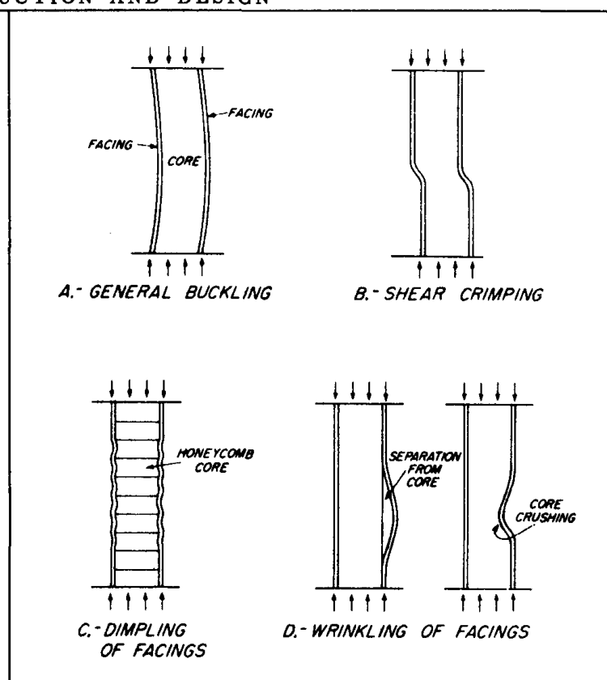

Fig. C12.2.1

せん断クリンプ破壊（Fig. C12.2.1B）は局所的な破壊モードのように見えるが、多くの場合、コアのせん断弾性率が低いために座屈の波長が極めて小さくなる、全体的な全体座屈（Fig. C12.2.1A）の一形態である。サンドイッチのクリンプ（折れ曲がり）は極めて突然発生し、通常はクリンプ部でコアのせん断破壊を引き起こす。また、面材とコアの間の接着部のせん断破壊を引き起こすこともある。クリンプは、サンドイッチの全体座屈と同時にも発生し得る。このような場合、全体的な座屈が現れ始め、全体座屈の端部における激しい局所せん断応力のために、クリンプが突然発生する。クリンプが発生するとすぐに、全体座屈は消失することがある。

したがって、破壊したサンドイッチの検査によりクリンプまたはせん断不安定性が示されたとしても、破壊は最終的にクリンプを引き起こした全体座屈によって始まっていた可能性がある。

コアがセル状（ハニカム）または波板材料である場合、Fig. C12.2.1C に示すように、面材がコアの壁間または波板の隙間に座屈またはディンプル（くぼみ）を生じることがある。この面材のディンプルは、ディンプルの振幅がコアのセル壁を越えて成長し、面材のしわ寄りに至るほど大きくならない限り、破壊につながらない可能性がある。全構造破壊を引き起こさないディンプルであっても、当然ながら、荷重を除去した後に永久的なディンプルが残るほど深刻な場合がある。

しわ寄り（リンクリング）は、Fig. C12.2.1D に示すように、面内圧縮を受けるサンドイッチ面材が弾性基礎上の平板として座屈する場合に発生し得る。面材とコアの接着部の平坦引張強度に対するコアの平坦圧縮強度に応じて、面材は内側または外側に座屈することがある。面材とコアの接着が強力な場合、面材がしわ寄り、コアに引張破壊を引き起こす可能性がある。したがって、しわ寄り荷重は、基礎システムの弾性と強度、すなわちコアおよび面材とコアの間の接着に依存する。面材は決して完全に平坦ではないため、しわ寄り荷重は初期の面材の偏心または元々のうねりにも依存する。

局所的な破壊モードは、面内荷重および／または面外荷重を受けるサンドイッチパネルで発生する可能性がある。全体座屈および局所破壊モードに加えて、面内荷重および／または面外荷重によって面材が引張、圧縮、せん断、または複合応力で破壊しないよう、また面外荷重によってコアがせん断または平坦圧縮で破壊しないようにサンドイッチを設計しなければならない。

基本的な設計原則は、以下の4つの必要条件として要約できる。

1. サンドイッチ面材は、設計荷重[^1]下で選択された設計応力に耐えるのに十分な厚さでなければならない。
2. コアは、設計荷重[^2]下で全体的なサンドイッチの座屈、過度なたわみ、またはせん断破壊が発生しないよう、十分な厚さとせん断剛性および強度を持たなければならない。
3. コアは十分に高い弾性率を持たなければならず、サンドイッチは、設計荷重[^3]下でいずれの面材のしわ寄りも発生しないよう、十分に大きな平坦引張および圧縮強度を持たなければならない。
4. コアがセル状（ハニカム）または波板材料であり、面材のディンプルが許容されない場合、セルサイズまたは波板の間隔は、設計荷重[^4]下でいずれの面材もコアの空間にディンプルを生じないよう、十分に小さくなければならない。

サンドイッチ組立の材料および方法の選択においては、サンドイッチが機能する環境を考慮しなければならず、設計に使用される材料特性は予想される環境と適合していなければならない。環境として含まれるのは、熱、冷気、水または水分、腐食性雰囲気または液体、疲労、クリープ、あるいは材料特性に影響を及ぼす可能性のあるその他の条件の影響である。適切な性能に関して可能な限り困難を未然に防ぐよう、設計の詳細を決定すべきである。

意図した目的に対して完全に効率的な設計に到達するためには、熱伝導率、表面摩耗に対する耐性、寸法安定性、透過性、および電気的特性などの特定の非構造的特性も考慮する必要がある。

構造設計に使用する公式およびグラフを示す詳細な手順は、C12の以下のセクションに記載されている。公式およびグラフは、様々なタイプの荷重下におけるサンドイッチ構成要素に必要なコア特性だけでなく、面材およびコアの寸法を決定するために使用できる。グラフと公式は一般的なパラメータの観点から提示されており、特定の材料のためのものではない。座屈を伴う設計基準は、理論的な座屈係数に基づいている。これらは平均的な試験結果と良好に一致しているが、座屈試験結果に特徴的なばらつきを考慮して、最終設計において、おそらくわずかに厚いコアを選択することにより、設計荷重[^5]でサンドイッチ構成要素の座屈が発生しないように余裕を持たせることができる。

## C12.3 記号（Nomenclature）

- $1$ - サンドイッチの面材1を表す下付き文字
- $2$ - サンドイッチの面材2を表す下付き文字
- $a, b$ - パネルの辺の長さ、 $b$ は圧縮荷重に平行
- $c$ - 「コア」または「圧縮」、コア深さを表す下付き文字
- $cr$ - 「臨界（クリティカル）」を表す下付き文字
- $D$ - 下付き文字に応じて曲げ剛性またはねじり剛性
- $d$ - サンドイッチの総深さまたは厚さ
- $E$ - ヤング率（縦弾性係数）
- $E'$ - 有効弾性率
- $F$ - 許容応力、下付き文字は面材を表す
- $f$ - 計算応力
- $G$ - 横弾性係数（せん断弾性率）
- $G'$ - 有効せん断弾性率
- $H$ - 伸張剛性
- $h$ - 面材図心間の距離
- $K$ - 定数
- $L$ - 長さ
- $M$ - 曲げモーメント
- $m$ - 半波の数
- $N$ - 辺の単位長さあたりの荷重
- $n$ - 半波の数
- $P$ - 荷重
- $p$ - 分布荷重の強度
- $r$ - 半径、「減少」を表す下付き文字
- $R$ - 比率
- $S$ - パネル表面に垂直なせん断荷重
- $s$ - コアのセルサイズ、応力に適用された場合は「せん断」、弾性率に適用された場合は「割線（セカント）」を表す下付き文字
- $T$ - トルク
- $t$ - 厚さ、下付き文字は厚さのタイプを表す、弾性率に適用された場合は「接線（タンジェント）」を表す下付き文字
- $U$ - 横せん断剛性
- $u$ - 応力に適用された場合の「極限（アルティメット）」を表す下付き文字
- $V$ - せん断剛性と曲げ剛性を関連付けるパラメータ
- $w$ - 密度、「しわ寄り（リンクリング）」を表す下付き文字
- $x$ - 軸、「x軸に平行」を表す下付き文字
- $y$ - x軸に垂直な軸、「y軸に平行」を表す下付き文字、または応力に適用された場合の「降伏（イールド）」を表す下付き文字
- $z$ - サンドイッチ表面に垂直な軸、「z軸に平行」を表す下付き文字
- $\gamma$ - せん断ひずみ
- $\delta$ - たわみ
- $\epsilon$ - 圧縮または伸張ひずみ
- $\eta$ - 塑性係数
- $\lambda$ - 1から2つのポアソン比の積を引いたもの
- $\mu$ - ポアソン比
- $\rho$ - 断面回転半径

## C12.4 サンドイッチの基本的な構造特性

### C12.4.1 サンドイッチの曲げ剛性

無視できる曲げ剛性のコアの上に薄い面材を持つサンドイッチは、単位幅あたり以下の公式で与えられる横剛性を持つ。

$$D = \frac{E'_1 t_1 E'_2 t_2 h^2}{(E'_1 t_1 + E'_2
t_2)\lambda} \quad \text{（不等厚面材の場合）} \tag{C12.4.1}$$

$$D = \frac{E' t_F h^2}{2\lambda} \quad \text{（等厚面材の場合）}
\tag{C12.4.1a}$$

ここで、 $E'$ は面材の有効弾性率、 $\lambda = 1 - \mu^2$ 、 $\mu$ は面材のポアソン比である（公式では $\mu = \mu_1 = \mu_2$ と仮定している）。 $t_F$ は面材の厚さ、 $h$ は面材の図心間の距離である。

面材が厚い場合、サンドイッチの剛性は以下の公式で与えられる。

$$D = \frac{E'_1 t_1 E'_2 t_2 h^2}{(E'_1 t_1 + E'_2
t_2)\lambda} + \frac{1}{12\lambda}(E'_1 t_1^3 + E'_2 t_2^3)
\tag{C12.4.2}$$

$$D = \frac{E' t h^2}{2\lambda} + \frac{E' t^3}{6\lambda}
\tag{C12.4.2a}$$

### C12.4.2 サンドイッチのせん断剛性

厚いコアの上にかなり薄い面材を持つサンドイッチは、単位幅あたり以下の公式でおおよそ与えられる横せん断剛性を持つ。

$$U = \frac{h^2}{c} G'_c \approx h G'_c \tag{C12.4.3}$$

ここで、 $c$ はコアの厚さ、 $G'_c$ は有効コアせん断弾性率である。

### C12.4.3 コアの特性

等方性の正方形セルハニカムコアおよび直交異方性の六角形セルコアの機械的特性を本セクションに示す。示されている値は、正方形セルコアが縦方向（フォイルリボンに平行）と横方向（フォイルリボンに垂直）で等しい特性を持つという理論に基づいている。直交異方性の場合は、縦方向と横方向の両方の値が与えられる。

ろう付けまたは接着接合されたハニカムサンドイッチ試験から得られたコア特性は、完全なろう付けノードフローまたは接着接合に対するものである。本セクションで提示するチャートは、経験的データから導き出された公式に基づいている。

### C12.4.4 コア密度

理論的な正方形セルコアの密度（ $\rho'_c$ ）は、セルサイズ（ $s$ ）、フォイルゲージ（ $t_c$ ）、および材料密度（ $\rho_c$ ）に関して以下のように表すことができる。

$$\rho'_c = \frac{2 t_c}{s} \rho_c \tag{C12.4.4}$$

理論的な六角形セルコアの密度（ $\rho'_c$ ）は、セルサイズ（ $s$ ）、フォイルゲージ（ $t_c$ ）、および材料密度（ $\rho_c$ ）に関して以下のように表すことができる。

$$\rho'_c = \frac{3 t_c}{s} \rho_c \tag{C12.4.5}$$

### C12.4.5 コアのせん断特性

#### ろう付け正方形セル

コアのせん断強度は、主にコア密度の関数として変化する。コアのせん断強度に影響を与えるその他の因子は以下の通りである。

- **a. コア深さ**: コア深さが増加すると、コアのせん断強度は低下する。
- **b. ろう付けノードフロー**: ノードフローが制限されているか、またはノードフローがない状態は、コアのせん断強度を低下させる。
- **c. リボン方向**: 横方向リボン強度の値には、縦方向リボン強度値の80%を使用する。
- **d. ろう付け合金**: ろう付け（コアと面の接合）強度は、以下の式で表すことができる。

$$F'_s = 1.25 \left(\frac{w}{s}\right) F_{sbr} \tag{C12.4.6}$$

ここで、 * $w$ = フィレット幅 * $s$ = セルサイズ * $F_{sbr}$ = ろう付け重ね合わせせん断強度

- **e. 温度**: 高温はコアのせん断強度とろう付け強度の両方を低下させる。ろう付け強度の高温による低下は、コアのせん断強度に対するものよりも大きいことに注意すべきである。したがって、室温でのコアせん断強度と高温でのろう付け強度に対して、ある構成が臨界（クリティカル）になる可能性がある。

設計コアせん断強度は、以下の実験式で表すことができる。

$\rho'_c < 18.0 \text{ lbs/ft}^3$ の場合：

$$F'_s = 1.307 \left(\frac{\rho'_c}{\rho_c}\right)^{1.34}
\frac{F_{su}}{c^{0.44}} \tag{C12.4.7}$$

$\rho'_c > 18.0 \text{ lbs/ft}^3$ の場合：

$$F'_s = 0.427 \left(\frac{\rho'_c}{\rho_c}\right)
\frac{F_{su}}{c^{0.44}} \tag{C12.4.8}$$

コアのせん断弾性率は、主にコア密度の関数として変化する。コアのせん断弾性率に影響を与えるその他の因子は以下の通りである。

- **a. リボン方向**: 横方向リボン方向の値には、縦方向リボン方向の値の70%を使用する。
- **b. 温度**: 温度低下は、コア材料のせん断弾性率の低下に比例する。

ノードフローの状態、コア深さ、およびセルサイズは、弾性率に直接影響を与えない。

コアのせん断弾性率の設計曲線は、以下の実験式で表すことができる。

$\rho'_c \ge 16.7 \text{ pcf}$ の場合：

$$G'_c = 0.4 \left(\frac{\rho'_c}{\rho_c}\right) G_c
\tag{C12.4.10}$$

試験データの大部分は、設計曲線と設計曲線の約240%の曲線の間に収まる。平均（中央値）値は、設計曲線の約128%である。試験ポイントの半分はこの平均を上回り、半分は下回る。理論弾性率は、以下の公式で表すことができる。

$$G'_c = 0.5 \left(\frac{\rho'_c}{\rho_c}\right) G_c
\tag{C12.4.11}$$

上記の理論式は、応力-ひずみ線図の初期部分でセル壁が座屈しないことを前提としている。しかし、実際の運用では、セル壁は非常に低い荷重レベルで座屈するか、あるいは製造時の初期座屈を有している。これにより、初期勾配が一般に理論値よりも小さくなる応力-ひずみ線図が部分的に説明される。

#### 接着接合六角形セルコア

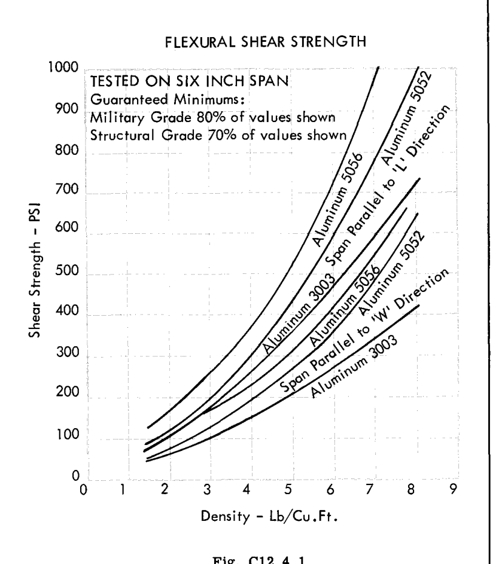

Fig. C12.4.1

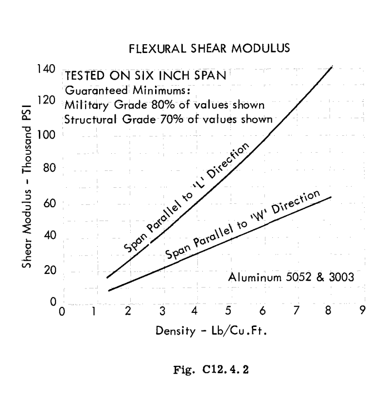

Fig. C12.4.2

### C12.4.6 コアの平坦圧縮特性

#### ろう付け正方形セル

コアの平坦圧縮強度は、主にコア密度の関数として変化する。コアの平坦圧縮強度に影響を与えるその他の因子は以下の通りである。

- **a. コア深さ**: コア深さが増加すると、強度は低下する。
- **b. ろう付けノードフロー**: ノードフローが制限されているか、またはノードフローがない状態は、強度を低下させる。
- **c. 温度**: 温度低下係数は経験的なものであり、高温では $F'_c$ が $F_{cy}$ に比例しなくなることを示している。

セルサイズとろう付け合金は強度に直接影響を与えない。

設計コア平坦圧縮強度は、以下の実験式で表すことができる。

$$F'_c = 2.31 \left(\frac{\rho'_c}{\rho_c}\right)^{1.464}
\frac{F_{cy}}{c^{0.18}} \tag{C12.4.12}$$

ここで、 $F_{cy}$ = 圧縮降伏応力である。

平均（中央値）は、設計コア強度の約115%である。

平坦圧縮弾性率はコア密度の関数である。ノードフロー、コア深さ、およびセルサイズは、弾性率に直接影響を与えない。高温値は室温値からの低下を示す。提示されている温度低下係数は経験的なものであり、高温では $E'_c$ が $E_c$ に比例しなくなることを示している。

コア圧縮弾性率の設計曲線は、以下の実験式で表すことができる。

$$E'_c = 2.13 \left(\frac{\rho'_c}{\rho_c}\right)^{1.418} E_c
\tag{C12.4.13}$$

試験データの大部分は、設計曲線と設計曲線の約250%の曲線の間に収まる。平均（中央値）値は、設計曲線の約157%である。試験ポイントの半分はこの平均を上回り、半分は下回る。

理論的なコア平坦圧縮弾性率は、以下の公式で表すことができる。

$$E'_c = \left(\frac{\rho'_c}{\rho_c}\right) E_c \tag{C12.4.14}$$

この公式は、セル壁の全断面積が軸方向応力によって均一にたわむことを前提としている。しかし、実際の運用では、ノード間のセル壁は比較的低い応力レベルで座屈し、ノードは均一な応力分布によって示されるよりも高い応力レベルで機能することが求められる。したがって、試験によって示されるコア圧縮弾性率の値は、理論値よりもかなり低くなる。

#### 接着接合六角形セルコア

ヤング率の場合、理論式は六角形セルコアの場合でも同様である。したがって、設計曲線を表すために式C12.4.12およびC12.4.13を使用することが提案されている。

### C12.4.7 コアの平坦引張特性

#### ろう付け正方形セルコア

コアの平坦引張強度は、主にコア密度の関数として変化する。コアの平坦引張強度に影響を与えるその他の因子は以下の通りである。

- **a. ノードフロー**: ノードフローが制限されているか、またはノードフローがない状態は、コアの平坦引張強度を低下させる。
- **b. ろう付け合金**: ろう付け（コアと面の接合）強度は、以下の式で表すことができる。

$$F'_t = 1.41 \left(\frac{w}{s}\right) F_{sbr} \tag{C12.4.15}$$

ここで、 $F_{sbr}$ = ろう付け重ね合わせせん断強度

- **c. 温度**: 高温はコアの平坦引張強度とろう付け強度の両方を低下させる。ろう付け強度の高温による低下は、コアの平坦引張強度に対するものよりも大きいことに注意すべきである。したがって、室温でのコア平坦引張強度と高温でのろう付け強度に対して、ある構成が臨界（クリティカル）になる可能性がある。

コア深さは強度に直接影響を与えない。

設計コア平坦引張強度は、以下の実験式で表すことができる。

$$F'_t = 0.5 \left(\frac{\rho'_c}{\rho_c}\right) F_{tu}
\tag{C12.4.16}$$

試験データの大部分は、設計曲線と設計曲線の160%の曲線の間に収まる。平均（中央値）は、設計曲線の約130%である。試験ポイントの半分はこの平均を上回り、半分は下回る。

#### 接着接合六角形セルコア

接着接合ハニカムパネルに対して、接着剤接合の影響を受ける平坦引張強度を計算するために、以下の式を使用することができる。

$$F'_t = \frac{b t_{AD}}{s} F_{SAD} \tag{C12.4.17}$$

ここで、 * $t_{AD}$ = 接着剤の厚さ * $F_{SAD}$ = 接着剤重ね合わせせん断強度

設計コア平坦引張強度は、式C12.4.16と同様である。

### C12.4.8 複合荷重強度

複合荷重強度の設計曲線は、以下の式で表すことができる。

$$R_a^2 + R_s = 1 \tag{C12.4.18}$$

ここで、

$$R_a = \frac{\text{加えられたコア垂直応力}}{\text{許容コア垂直応力}} =
\frac{f'_c}{F'_c} \text{ または } \frac{f'_t}{F'_t}$$

$$R_s = \frac{\text{加えられたコアせん断応力}}{\text{許容コアせん断応力}}
= \frac{f'_s}{F'_s}$$

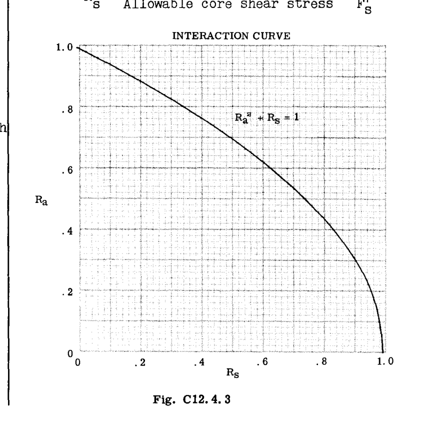

Fig. C12.4.3

### C12.4.9 その他の等方性コア

航空機業界では、波板コアの概念とともにハニカムコアが最も多く使用されているが、他のコア材料も多くの用途を見出している。コアとして使用されるより重要な材料は、バルサ材や発泡プラスチックと考えられている。密度、引張、圧縮、およびせん断許容量、圧縮およびせん断弾性率などのコア特性は、製造業者のハンドブックで見つけることができる。これらのコア材料はハニカムとほぼ同様に扱うことができるが、一般に効率が低く、コストが低くなる。

## C12.5 ハニカムフラットパネルの破壊モード

### C12.5.1 概要

ハニカムサンドイッチは、3つの形態の局所不安定性の対象となる。それらは、(1) セル内座屈（イントラセル座屈）、(2) 面材のしわ寄り（フェイスシートリンクリング）、および (3) せん断クリンピングである（セクションC12.2参照）。

一般に、セル内座屈は薄い面材を持つ部材に対して臨界（クリティカル）になり、しわ寄りは低密度コアに対して臨界になり、せん断クリンピングは低密度コアと高い $K_t (t_F/c)$ 値の組み合わせに対して臨界になる。

### C12.5.2 セル内座屈

#### C12.5.2.1 圧縮

セル内座屈は、面材の局所的な不安定破壊である。セルサイズと材料を一定に保ちながら面材の厚さを減少させると、面材がセル壁間で破壊する特定の厚さに達する。典型的なセル内座屈破壊を Fig. C12.5.1 に示す。

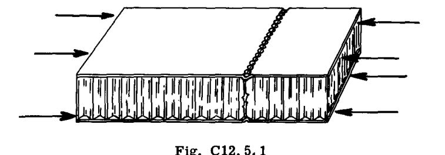

Fig. C12.5.1

以下のセクションにおける実験的なセル内座屈式は、試験から開発された。これらの許容量を満たすか、または超える確率は不明であるが、選択された許容量は、将来のほぼすべてのサンドイッチ試験で満たされるであろう。

セル内座屈応力は、主に面材の厚さとセルサイズの関数として変化する。コア密度、コア深さ、およびノードフローの状態は、セル内座屈応力に直接影響を与えない。横方向リボン方向の影響は無視できる。

リボン方向の一軸圧縮荷重下でのセル内座屈破壊の設計曲線は、以下の式で表すことができる。

$$\frac{F_{ci}}{\eta} = 0.75 E_f \left(\frac{t_F}{s}\right)^{3/2}
\tag{C12.5.1}$$

ここで、

$$\eta = \frac{2 E_T}{E_f + E_T} \quad \left(F_{ci} \text{ の場合}\right)
\tag{C12.5.2}$$

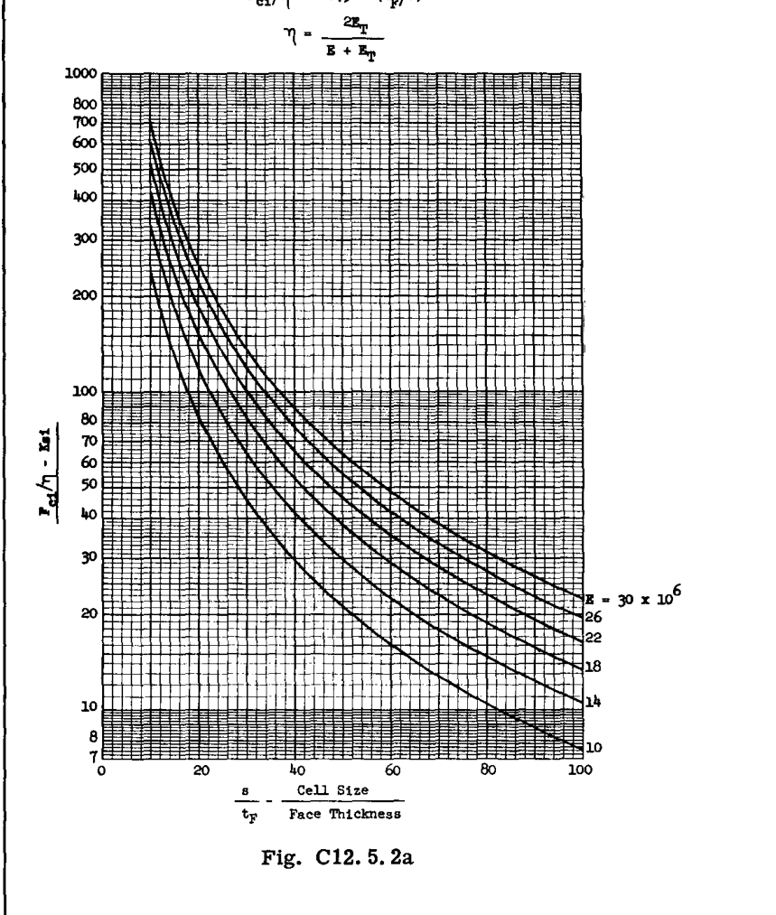

Fig. C12.5.2a

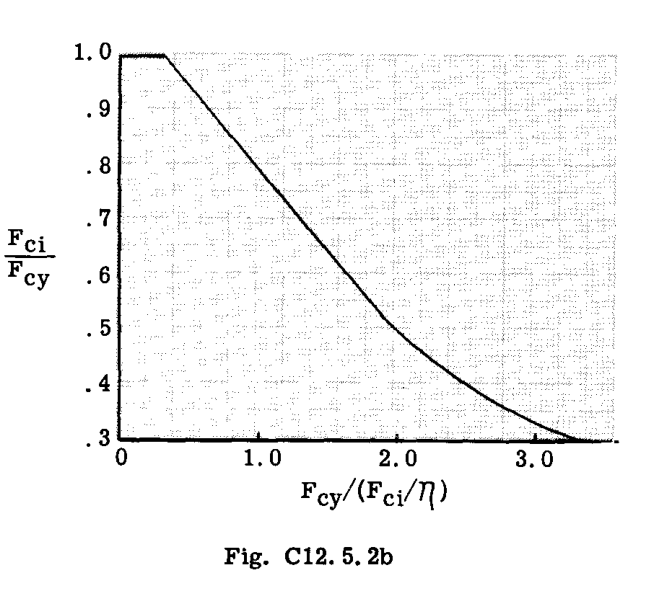

Fig. C12.5.2b

平均（中央値）は、以下の式で表すことができる。

$$\frac{F_{ci}}{\eta} = 0.9 E_f \left(\frac{t_F}{s}\right)^{3/2}$$

セル内座屈破壊に対する部材を解析する手順は以下の通りである。

1. 荷重がリボン方向に垂直および平行になるように荷重の向きを合わせる（Fig. C12.5.3a および C12.5.3b 参照）。

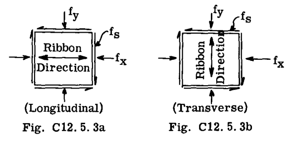

Fig. C12.5.3

注: * a. $f_x > f_y$ * b. $f_x$ は圧縮 * c. $f_y$ は圧縮または引張のいずれでもよい

これは通常、荷重が提示される方法である。

以下の例は、部材を解析する方法を示している。

**与条件**: 1. 材料: PH15-7Mo (RH1050) 室温 2. 特性: * $E_f = 30 \times 10^6 \text{ psi}$ * $F_{cy} = 190,000 \text{ psi}$ 3. 形状: * $s = 3/16 \text{ in.}$ * $t_F = 0.006 \text{ in.}$ 4. 荷重: * $f_x = 110,000 \text{ psi}$

$$\frac{F_{ci}}{\eta} = 129,000 \text{ psi} \quad \text{（Fig. C12.5.2a
または 式 C12.5.1 参照）}$$

$$\gamma_1 = 1.0 \quad \text{（C12.52ページ参照）}$$

$$F_{ci} = 190,000 \times 0.65$$

$$F_{ci} = 124,000 \text{ psi} \quad \text{（Fig. C12.5.2b 参照）}$$

$$M.S. = \frac{F_{ci}}{f_x} - 1 = 0.13$$

#### C12.5.2.2 せん断

せん断荷重下でのセル内座屈破壊の設計曲線（Fig. C12.5.4 参照）は、以下の式で表すことができる。

$$\frac{F_{si}}{\eta} = 0.6 E_f \left(\frac{t_F}{s}\right)^{3/2}
\tag{C12.5.3}$$

ここで、

$$\eta = \frac{2 E_T}{E_f + E_T} \quad \left(F_1 = \sqrt{3} F_{si} \text{
の場合}\right) \tag{C12.5.4}$$

$$\therefore \gamma_1 \text{ (Stress Intensity Ratio)} = \sqrt{3}$$

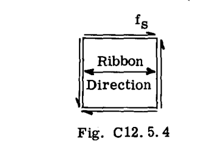

Fig. C12.5.4

以下の例は、部材を解析する方法を示している。

**与条件**: 1. 材料: PH15-7Mo (RH1050) 室温 2. 特性: * $E_f = 30 \times 10^6 \text{ psi}$ * $F_{cy} = 190,000 \text{ psi}$ 3. 形状: * $s = 3/16 \text{ in.}$ * $t_F = 0.006 \text{ in.}$ 4. 荷重: * $f_s = 80,000 \text{ psi}$

$$\frac{F_{ci}}{\eta} = 129,000 \text{ psi} \quad \text{（Fig. C12.5.2a
参照）}$$

$$\frac{F_{si}}{\eta} = 0.8 \times \frac{F_{ci}}{\eta} = 0.8 \times
129,000 = 103,200 \text{ psi}$$

注：係数0.8は常に適用可能 = $\frac{0.6}{0.75}$

$$\gamma_1 = \sqrt{3}$$

$$\frac{F_1}{\eta} = 103,200 \times \sqrt{3} = 178,000 \text{ psi}$$

$$F_1 = 145,000 \text{ psi} \quad \text{（Fig. C12.5.2b 参照）}$$

$F_1$ = 応力強さ - Von Misesの降伏基準

$$F_{si} = \frac{145,000}{\sqrt{3}} = 84,000 \text{ psi}$$

$$M.S. = \frac{F_{si}}{f_s} - 1 = 0.05$$

#### C12.5.2.3 二軸荷重

リボン方向に平行または垂直な二軸荷重に対するセル内座屈破壊の設計曲線は、以下の式で表すことができる。

##### 1. $f_y$ が圧縮の場合

$$R_x^n + R_y^n = 1 \tag{C12.5.5}$$

または

$$F_{cix} = \frac{F_{ci}}{\sqrt[n]{1 + \gamma^n}} \tag{C12.5.6}$$

- **a.** $s/t_F \ge 15.63$ の場合
  $$n = 3$$
- **b.** $s/t_F < 15.63$ の場合
  $$n = 2 +
  \left(\frac{15.63}{s/t_F}\right)^2$$

ここで、 * $R_x = f_x / F_{ci}$ * $R_y = f_y / F_{ci}$ * $\gamma = f_y / f_x$ * $F_{ci}$ = 一軸セル内許容値（セクション3.11参照） * $s$ = セルサイズ * $t_F$ = 面材の厚さ

##### 2. $f_y$ が引張の場合

$$R_x^2 + R_y = 1 \tag{C12.5.7}$$

ここで、 * $R_y = \frac{f_y}{F_{tu}}$ * $R_x = \frac{f_x}{F_{ci}}$

#### C12.5.2.4 二軸およびせん断荷重

二軸およびせん断荷重を受ける部材のセル内座屈破壊の設計曲線（Fig. C12.5.5a または C12.5.5b 参照）は、以下の式で表すことができる。

$$R_a + R_s^2 = 1 \tag{C12.5.8}$$

および

$$M.S. = \frac{2}{R_a + (R_a^2 + 4 R_s^2)^{1/2}} - 1 \tag{C12.5.9}$$

ここで、 * $R_a = \frac{f_x}{F_{cix}}$ * $R_s = \frac{f_s}{F_{si}}$ * $F_{cix}$ = 二軸荷重のみの場合のx方向の許容荷重（セクションC12.5.2.1参照） * $F_{si}$ = せん断荷重のみの場合の部材の許容荷重（セクションC12.5.2.2参照）

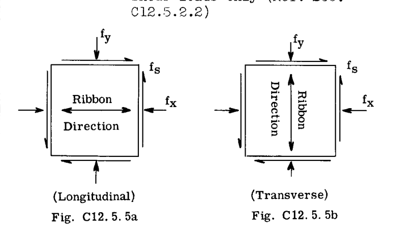

Fig. C12.5.5

注： * a. $f_x > f_y$ * b. $f_x$ は圧縮 * c. $f_y$ は圧縮または引張のいずれでもよい

以下の例は、部材を解析する方法を示している。

**与条件**: 1. 材料: PH15-7Mo (RH1050) 室温 2. 特性: * $E_f = 30 \times 10^6 \text{ psi}$ * $F_{cy} = 190,000 \text{ psi}$ 3. 形状: * $s = 3/16 \text{ in.}$ * $t_F = 0.006 \text{ in.}$ 4. 荷重: * $f_x = 100,000 \text{ psi}$ * $f_y = 50,000 \text{ psi}$ * $f_s = 20,000 \text{ psi}$

**手順**:

**手法A - 具体的な解**

1. $F_{cix} = 124,000 \text{ psi}$ (セクションC12.5.2.1参照)
2. $F_{si} = 84,000 \text{ psi}$ (セクションC12.5.2.2参照)
3. $R_a = \frac{f_x}{F_{cix}} = \frac{100,000}{124,000} = 0.806$
   $$R_s = \frac{f_s}{F_{si}} = \frac{20,000}{84,000}
   = 0.238$$

$$M.S. = \frac{2}{R_a + (R_a^2 + 4 R_s^2)^{1/2}} - 1 = 0.15$$

### C12.5.3 しわ寄り（リンクリング）

ハニカムサンドイッチの面材のしわ寄り現象は、弾性基礎上の薄い板の安定性の問題である。2つの異なる破壊モードが可能であり、対称的（Fig. C12.5.6a）および非対称的（Fig. C12.5.6b）である。 $K_t (t_F/c)$ の値が大きい場合、しわは非対称になり、一方 $K_t$ の値が小さい場合は、しわは対称になる。

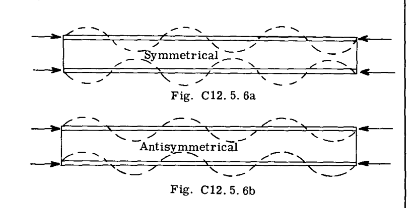

Fig. C12.5.6

セクションC12.5.3.1からC12.5.3.4の実験的なしわ寄り式は試験から開発されたものであり、両方のタイプの破壊に適用可能である。これらの許容量を満たすか、または超える確率は不明であるが、選択された許容量は、将来のほぼすべてのサンドイッチ試験で満たされるであろう。

しわ寄り許容量は、主にコア密度の関数として変化する。横方向リボン値は、縦方向値からの低下（0.95）を示す。ノードフロー、コア深さ、面材の厚さ、およびセルサイズは、許容量に直接影響を与えない。

#### C12.5.3.1 圧縮

リボン方向の一軸圧縮荷重下でのしわ寄り破壊の設計曲線は、以下の式で表すことができる。

$$\frac{F_{cw}}{\eta_2} = 0.43 \sqrt[3]{E_f E'_c G'_c}
\tag{C12.5.10}$$

ここで、

$$\eta_2 = \sqrt[3]{\frac{3 E_T + E_s}{4 E_f}} \quad \left(F_{cw} \text{
の場合}\right) \tag{C12.5.11}$$

平均（中央値）値は、設計値の約120%である。

以下の例は、一軸圧縮を受ける部材を解析する方法を示している。

**与条件**: 1. 材料: PH15-7Mo (RH1050) 室温 2. 特性: * $E = 30 \times 10^6 \text{ psi}$ * $F_{cy} = 190,000 \text{ psi}$ 3. 形状: * $s \times t_c = 3/16 \times 0.001 \text{ in.}$ * $\rho'_c = 5.4 \text{ pcf}$ 縦方向リボン方向 4. 荷重: * $f_x = 120,000 \text{ psi}$
$$s/t_c = 187.5$$

$$\frac{F_{cw}}{\eta_2} = 182,000 \text{ psi} \quad \text{（式C12.5.10
または Fig. C12.5.7a 参照）}$$

$$\gamma_1 = 1.0 \quad \text{（一軸圧縮）}$$

$$F_{cw} = 158,000 \text{ psi} \quad \text{（式C12.5.11 または Fig.
C12.5.7b 参照）}$$

$$M.S. = \frac{F_{cw}}{f_x} - 1 = 0.32$$

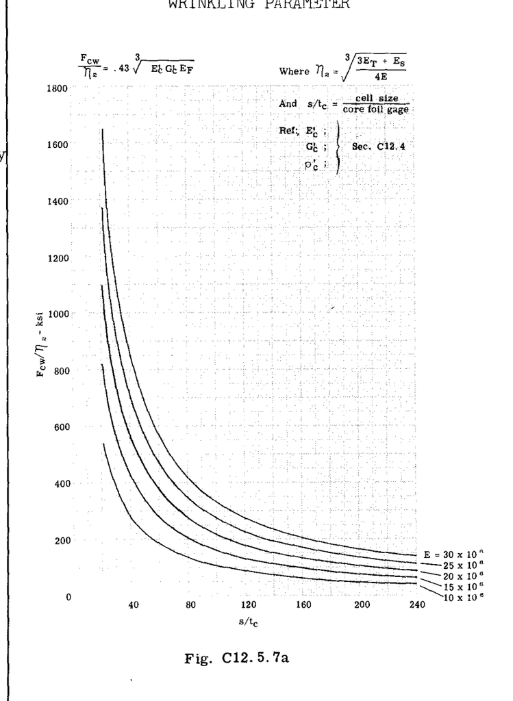

Fig. C12.5.7a

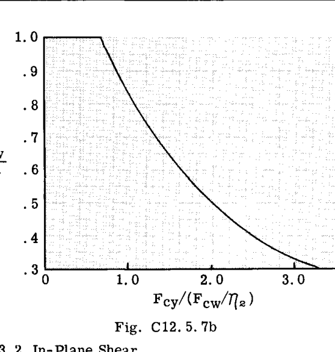

Fig. C12.5.7b

#### C12.5.3.2 面内せん断

せん断荷重下でのハニカムサンドイッチ部材のしわ寄り破壊の設計曲線は、以下の式で表すことができる。

$$\frac{F_{sw}}{\eta_2} = 0.43 \sqrt[3]{E_f E'_c G'_c}
\tag{C12.5.12}$$

ここで、

$$\eta_2 = \sqrt[3]{\frac{3 E_T + E_s}{4 E}} \quad \left(F_1 = \sqrt{3}
F_{sw} \text{ の場合}\right)$$

$$\therefore \gamma_1 = \sqrt{3}$$

以下の例は、部材を解析する方法を示している。

**与条件**: 1. 材料: PH15-7Mo 鋼 (RH1050) 室温 2. 特性: * $E = 30 \times 10^6 \text{ psi}$ * $F_{cy} = 190,000 \text{ psi}$ 3. 形状: * $s \times t_c = 3/16 \times 0.001 \text{ in.}$ * $\rho'_c = 5.4 \text{ lb/ft}^3$ 4. 荷重: * $f_s = 100,000 \text{ psi}$
$$s/t_c =
187.5$$

$$\frac{F_{sw}}{\eta_2} = 182,000 \text{ psi} \quad \text{（Fig. C12.5.7a
参照）}$$

注：

$$\frac{F_{sw}}{\eta_2} = \frac{F_{cw}}{\eta_2}$$

$$\gamma_1 = \sqrt{3}$$

$$F_1 / \eta = 182,000 \times \sqrt{3} = 314,000$$

$$F_i = 190,000 \text{ psi} \quad \text{（Fig. C12.5.7b 参照）}$$

$$F_{sw} = \frac{190,000}{\sqrt{3}} = 110,500 \text{ psi}$$

$$M.S. = \frac{F_{sw}}{f_s} - 1 = 0.10$$

#### C12.5.3.3 二軸荷重

リボン方向（縦方向）に主荷重を持つ二軸荷重下での部材のしわ寄り破壊の設計曲線は、以下の式で表すことができる。

##### 1. $f_y$ が圧縮の場合

$$\frac{F_{cwx}}{\eta_2} = \frac{0.43 \sqrt[3]{E_f E'_c
G'_c}}{\sqrt[3]{1 + \gamma^3}} \tag{C12.5.13}$$

##### 2. $f_y$ が引張の場合

$$\frac{F_{cwx}}{\eta_2} = 0.43 \sqrt[3]{E_f E'_c G'_c}
\tag{C12.5.14}$$

ここで、

$$\eta_2 = \sqrt[3]{\frac{3 E_T + E_s}{4 E_f}} \quad \left(F_1 = \gamma_1
F_{cwx} \text{ の場合}\right)$$

$$\gamma = f_y / f_x$$

$$\gamma_1 = \sqrt{1 - \gamma + \gamma^2} \tag{C12.5.15}$$

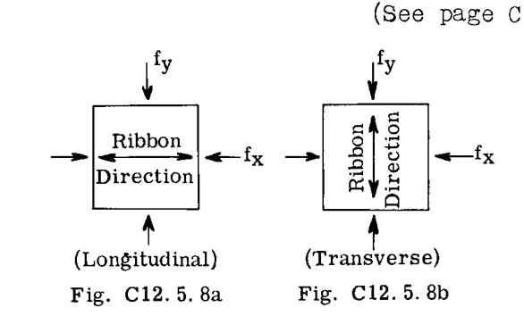

Fig. C12.5.8

以下の例は、部材を解析する方法を示している。

**例 1**

**与条件**: 1. 材料: PH15-7Mo (RH1050) 室温 2. 特性: * $E = 30 \times 10^6 \text{ psi}$ * $F_{cy} = 190,000 \text{ psi}$ 3. 形状: * $s \times t_c = 3/16 \times 0.001 \text{ in.}$ * $\rho'_c = 5.4 \text{ pcf}$ 縦方向リボン方向 4. 荷重: * $f_x = 120,000 \text{ psi}$ (圧縮) * $f_y = 60,000 \text{ psi}$ (圧縮) * $\gamma = f_y/f_x = 0.5$

$$\frac{s}{t_c} = \frac{3/16}{0.001} = 187.5$$

$$\frac{F_{cw}}{\eta_2} = 182,000 \text{ psi} \quad \text{（Fig. C12.5.7a
参照）}$$

$$\gamma_1 = \sqrt{1 - \gamma + \gamma^2} = 0.866$$

$$\frac{F_{cwx}}{\eta_2} = \frac{F_{cw}/\eta_2}{\sqrt[3]{1 + \gamma^3}} =
\frac{182,000}{1.040} = 175,000 \text{ psi}$$

$$F_1 / \eta = 175,000 \times 0.866 = 152,000 \text{ psi}$$

$$F_{1x} = 142,000 \text{ psi} \quad \text{（Fig. C12.5.7b 参照）}$$

$$F_{cwx} = \frac{142,000}{0.866} = 164,000 \text{ psi}$$

$$M.S. = \frac{F_{cwx}}{f_x} - 1 = 0.37$$

**例 2**

**与条件**: 例1と同じ形状、横方向リボン方向

- 荷重:
  - $f_x = 120,000 \text{ psi}$ (圧縮)
  - $f_y = -30,000 \text{ psi}$ (引張)
  - $\gamma = -0.25$

$$\frac{s}{t_c} = \frac{3/16}{0.001} = 187.5$$

$$\frac{F_{cw}}{\eta_2} = 182,000 \text{ psi} \quad \text{（Fig. C12.5.7a
参照）}$$

$$\gamma_1 = \sqrt{1 - \gamma + \gamma^2} = 1.147$$

$$F_{cwx} = 150,000 \text{ psi} \quad \text{（Fig. C12.5.7b
参照、横方向リボン用）}$$

$$F_{cwx} = 0.95 \times 150,000 = 143,000 \text{ psi}$$

$$M.S. = \frac{F_{cwx}}{f_x} - 1 = 0.19$$

#### C12.5.3.4 二軸およびせん断荷重

二軸およびせん断荷重を受ける部材のしわ寄り破壊の設計曲線（Fig. C12.5.9a または C12.5.9b 参照）は、以下の式で表すことができる。

$$R_a + R_s^2 = 1 \tag{C12.5.16}$$

および

$$M.S. = \frac{2}{R_a + \sqrt{R_a^2 + 4 R_s^2}} - 1 \tag{C12.5.17}$$

ここで、 * $R_a = \frac{f_x}{F_{cwx}}$ * $R_s = \frac{f_s}{F_{sw}}$ * $F_{cwx}$ = 二軸荷重のみの場合のx方向の許容荷重（セクションC12.5.3.3参照） * $F_{sw}$ = せん断荷重のみの場合の部材の許容荷重（セクションC12.5.3.2参照）

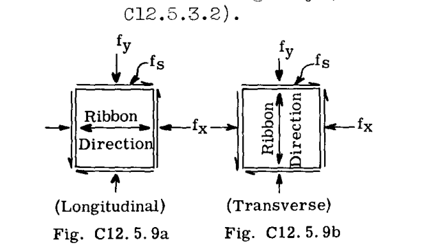

Fig. C12.5.9

注： * a. $f_x > f_y$ * b. $f_x$ は圧縮 * c. $f_y$ は圧縮または引張のいずれでもよい

以下の例は、部材を解析する方法を示している。

**与条件**: 1. 材料: PH15-7Mo (RH1050) 室温 2. 特性: * $E = 30 \times 10^6 \text{ psi}$ * $F_{cy} = 190,000 \text{ psi}$ 3. 形状: * $s \times t_c = 3/16 \times 0.001 \text{ in.}$ * $\rho'_c = 5.4 \text{ pcf}$ 縦方向リボン方向 4. 荷重: * $f_x = 120,000 \text{ psi}$ (圧縮) * $f_y = 60,000 \text{ psi}$ (圧縮) * $f_s = 60,000 \text{ psi}$

$$F_{cwx} = 164,000 \text{ psi} \quad \text{（セクションC12.5.3.3
例1参照）}$$

$$F_{sw} = 110,500 \text{ psi} \quad \text{（セクションC12.5.3.2 参照）}$$

$$R_a = \frac{f_x}{F_{cwx}} = \frac{120,000}{164,000} = 0.73$$

## C12.5.4 せん断クリンピング

せん断クリンピング破壊は、コアのせん断弾性率が低いために座屈の波長が非常に小さくなる、全体的な不安定破壊の一形態である。この破壊は突然発生し、クリンプ部でコアがせん断破壊する原因となる。

臨界（クリティカル）せん断クリンピング応力を計算するために、以下の式が使用される。

$$F_{cs_{max}} = \frac{U}{2 t_F} = \frac{G'_c(c + 2 t_F)}{2 t_F}
\tag{C12.5.18}$$

ここで、 $F_{cs_{max}}$ = 最大主応力の方向における最大許容せん断クリンピング応力

以下の例は、部材を解析する方法を示している。

**与条件**: 1. 材料: PH15-7Mo (RH1050) 室温 2. 形状: * $t_F = 0.050 \text{ in.}$ * $c = 0.55 \text{ in.}$ * $s \times t_c = 3/16 \times 0.001 \text{ in.}$ * $\rho'_c = 5.4 \text{ pcf}$ * $G'_c = 27,600 \text{ psi}$ 3. 荷重: * $f_x = 150,000 \text{ psi}$ (圧縮) * $f_y = -10,000 \text{ psi}$ (引張) * $f_s = 68,000 \text{ psi}$ * $\therefore f_{max} = 175,000 \text{ psi}$ (モールの応力円より)

**手順**:

$$F_{cs_{max}} = \frac{G'_c(c + 2 t_F)}{2 t_F} = \frac{27,600 \times
0.65}{0.10} = 179,500 \text{ psi}$$

$$M.S. = \frac{F_{cs_{max}}}{f_{max}} - 1 = 0.03$$

## C12.5.5 全体不安定性 - 一軸圧縮

**全体座屈許容量** - このセクションでは、一般的な圧縮座屈許容量を提示する。これらは、特定の材料に限定されないという点で一般的である。

圧縮座屈方程式は以下の通りである。

$$\frac{F_{ccr}}{\eta} = \frac{K_c}{J} \times \frac{U}{2 t_F}
\tag{C12.5.19}$$

以下の例は、圧縮座屈許容量を求める方法を示している。

**与条件**: 1. 材料: PH15-7Mo (RH1050) 室温 2. 特性: * $E = 30 \times 10^6 \text{ psi}$ * $G'_c = 38,000 \text{ psi}$ ( $s = 3/16 \text{ in.}$ , $t = 0.001 \text{ in.}$ ) * $F_{cy} = 190,000 \text{ psi}$ 3. 形状: * $c = 0.50 \text{ in.}$ * $t_F = 0.010 \text{ in.}$ * $a = 40 \text{ in.}$ * $b = 20 \text{ in.}$ 4. 境界条件: 四辺単純支持

**計算**: